# Digital Methods project, The Kings In the Mirror Of The Funeral Sermons

### Combining the samples

When looking at the word counts, it becomes clear that I need to create a stopword list. By initially merging the two sets of word samples and then calculating the total word frequency across both sermons, followed by sorting them based on the most frequently occurring words, I can create a stopword list that encompasses both sermons. Therefore, I will begin the process of combining the samples, which will also simplify the visualization process

```r
# Combining the date in one dataset

combined_data <- full_join(fred_sampled_counts, chris_sampled_counts, by = "word") %>%
  rename(frederik_word_counts = n.x) %>%
  rename(christian_word_counts = n.y)

colnames(combined_data)
```

```
## [1] "word"                  "frederik_word_counts"  "christian_word_counts"
```

I will now create a now column, based on the sum of the words counts in both sermons, using the rowSums function. Using both sermons to create a stopwordlist, is helpfull because of the variation of spelling

```r
# Preparing for the stopword list

combined_data$sum_counts <- rowSums(combined_data[, c("frederik_word_counts", "christian_word_counts")], na.rm = TRUE)

# Arranging the data by the highest word counts in the 'sum_counts' column
combined_data <- combined_data %>%
  arrange(desc(sum_counts))

combined_data%>%
  head(20)
```

```
##    word frederik_word_counts christian_word_counts sum_counts
## 1    oc                  875                  1101       1976
## 2    at                  335                   332        667
## 3   som                  389                   176        565
## 4     i                  191                   249        440
## 5   den                  172                   237        409
## 6  hand                   90                   280        370
## 7   det                  201                   159        360
## 8   der                  200                   152        352
## 9   til                  175                   172        347
## 10   er                  192                   137        329
## 11  aff                  188                   130        318
## 12  udi                  170                   125        295
## 13   en                  119                   158        277
## 14 hans                  161                   102        263
## 15  gud                  102                   157        259
## 16  saa                  146                   109        255
## 17 icke                  125                   126        251
## 18   de                  145                    91        236
## 19  paa                  146                    86        232
## 20  sig                  124                    95        219
```

As it now is visible, each variable has its own column, and each observation has its own row. This format makes it easier to work with and analyze data, as it follows a clear and structured form where the information is organized in a table. Also a new column has been made with the sum of the counts of each word in the different sermons. but more important, the word column has been sorted after the value in the sum_counts column, in the dataset combined_data

### Creating and removing stopwords

Again it is pretty clear that it would be necesarry to remove all the stop words, but the spelling of 17’th century old danish text is not the same as today, and a stopwordlist with these old words does not exist. Therefore i will partially use R to create one. I will take the list of the most frequent words across the two sermons, calculated before, and then manually sort the list in Excel, because some words like “gud” [englis god] has a high frequency, but is relevant to my further analysis.

Now i will take the word column which i arranged after sum_counts before, and extract it from the combined_data dataset

```r
# Extract the word column

word_column <- combined_data %>%
  select(word)
```

I will take the first 200 words, insert them into excel, and then manually remove interesting words from the list. I ended up removing the following words:

From, gud, guds, herre, naade, david, herren, mand, gode, konge, konning, konge, stor, ære, fader, kong, første, fred, god, raad, hertug, ord mayst, hierte, hellige, kongelig, høy, høye, søn, unge, fromme, herris, største, høyborne, glæde, danmarckis, undersaatter, allernaadigste naadige, regiering, propheten, salig

#### Loading stopwordlist

After the alterations in Excel, i can upload the Excel file into R

```r
# Loading stopwordlist

stop_word <- read_delim("Data/stop_word_list.csv", delim = ";", col_types = cols(.default = "c")) %>%
  filter(!is.na(word)) %>%
  select(word)
stop_word
```

```
## # A tibble: 176 × 1
##    word
##    <chr>
##  1 oc
##  2 at
##  3 som
##  4 i
##  5 den
##  6 det
##  7 hand
##  8 til
##  9 der
## 10 er
## # ℹ 166 more rows
```

#### Removing the stopwords

Now i will remove the stopwords from the samples

```r
# Removing stopwords from the combined dataset

combined_filtered <- combined_data %>%
  filter(!word %in% stop_word$word) %>%
  arrange(desc(sum_counts))

combined_filtered%>%
  head(20)
```

```
##       word frederik_word_counts christian_word_counts sum_counts
## 1      gud                  102                   157        259
## 2     guds                   63                    98        161
## 3    herre                   56                    64        120
## 4    naade                   73                    30        103
## 5     mand                   47                    20         67
## 6    david                   10                    55         65
## 7     gode                   35                    24         59
## 8   herren                   31                    27         58
## 9    konge                    4                    53         57
## 10     ære                   12                    41         53
## 11   fader                   34                    15         49
## 12 konning                   16                    32         48
## 13   store                   12                    34         46
## 14  første                   28                    17         45
## 15    stor                   20                    25         45
## 16    kong                   38                     3         41
## 17     god                   17                    23         40
## 18    fred                   14                    22         36
## 19  hertug                   31                     4         35
## 20   mayst                   NA                    32         32
```

# Comparing and visualizing

In this section i will start using the data to make visualizations. In the following part i will be looking at, the most common words in the funeral sermons, after i have removed the stopwords

### Looking at the most common words in each funeral sermon sampel

To look at the 20 most common words i will extract the word column and the counts from each of the two sermons, and thereafter arrange them from higest to lowest, and then using the head() function, which we worked with in class, taking the 20 most common words. I am Coloring the graphs, and the colors will be consistent, so that the word counts from Christian IV’s funeral sermon always will be blue, and counts from Frederik II will be consistently red.

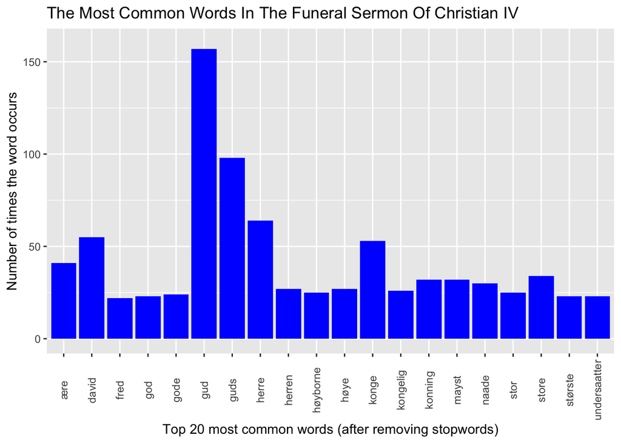

```r
# Looking at top 20 most common words

# Christian IV
chris_top_20_words <- combined_filtered %>%
  select(word,christian_word_counts) %>%
  arrange(desc(christian_word_counts)) %>%
  head(20)

chris_top_20_words_gg <- chris_top_20_words%>%
  ggplot(aes(x=word,y=christian_word_counts))+
  geom_col(fill = "blue") +
  theme(axis.text.x=element_text(angle=90,vjust=0.5))+
  labs(title="The Most Common Words In The Funeral Sermon Of Christian IV",x="Top 20 most common words (after removing stopwords)", y= "Number of times the word occurs")+
  ylim(0, 160)

chris_top_20_words_gg
```

```r
# Save it in the visualizations folder
ggsave(plot = chris_top_20_words_gg,
       here("visualizations","chris_top_20_words.png"),
       height = 5,
       width = 8)
```

I will be doing the same to the sermon of Frederik II. i am using ylim() to set the y-axis limits to be the same in both plots, because it ensures that the y-axis scales are identical, making it easier to compare word counts between the two sermons.

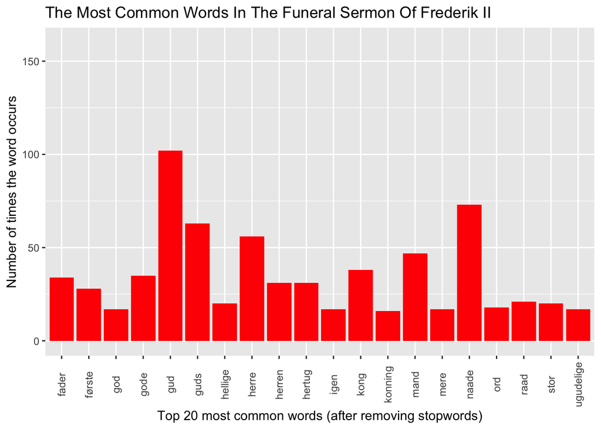

```r
# Looking at top 20 most common words

# Frederik II
fred_top_20_words <- combined_filtered %>%
  select(word,frederik_word_counts) %>%
  arrange(desc(frederik_word_counts)) %>%
  head(20)

fred_top_20_words_gg <- fred_top_20_words%>%
  ggplot(aes(x=word,y=frederik_word_counts)) +
  geom_col(fill = "red") +
  theme(axis.text.x=element_text(angle=90,vjust=0.5)) +
   labs(title="The Most Common Words In The Funeral Sermon Of Frederik II",x="Top 20 most common words (after removing stopwords)", y= "Number of times the word occurs") +
  ylim(0, 160)

fred_top_20_words_gg
```

```r
# Save it
ggsave(plot = fred_top_20_words_gg,
       here("visualizations","fred_top_20_words.png"),
       height = 5,
       width = 8)
```

### Comparing word categories

To find out how the ideal king’s role changed during the reign of Christian IV, I will use and create visualizations and plots for different word categories. To create these categories, I read both of the sermons and took notes in between, jotting down words that might be relevant and be a part of different gruops.

To find all the variations of the words, I will use the shortest form of each word so that different suffixes are also counted. I will be examining words related to:

- Titles of the kings (the names and titles used to address the king).
- Person Traits, adjectives used to descripe the kings personality
- The king’s role as a church leader.
- Words concerning the king’s education.
- War and crisis
- Word regarding the status of the king
- Subjects’ groups, other groups/persons mentioned in the text

This approach will help me compare and visualize how the perception of an ideal king’s role evolved during Christian IV’s reign in various contexts and aspects.

#### Words regarding to Religion

In the following section, i will be looking at words, regarding the church, But first i will have to find all the versions of the different words i am interested in using ignore.case = TRUE, so that e.g. both “kircke” [church] and “kircker” [churches] gets included. I will be grouping all the variations under one term, using the grepl() function

```r
# Grouping words related to religion

church_group_data <- combined_filtered %>%
  mutate(grouped_church_word = case_when(
  grepl("salig", word, ignore.case = TRUE) ~ "salig",
  grepl("psalme", word, ignore.case = TRUE) ~ "psalme",
  grepl("gudfrycti", word, ignore.case = TRUE) ~ "gudfryctig",
  grepl("gud", word, ignore.case = TRUE) ~ "gud",
  grepl("isreal", word, ignore.case = TRUE) ~ "isreal",
  grepl("synd", word, ignore.case = TRUE) ~ "synd",
  grepl("sathan|satan", word, ignore.case = TRUE) ~ "sathan",
  grepl("kirck", word, ignore.case = TRUE) ~ "kirck",
  grepl("salomon", word, ignore.case = TRUE) ~ "salomon",
  grepl("jesu", word, ignore.case = TRUE) ~ "jesu",
  grepl("eliam", word, ignore.case = TRUE) ~ "eliam",
  grepl("elizæus", word, ignore.case = TRUE) ~ "elizæus",
  grepl("hellig", word, ignore.case = TRUE) ~ "hellig",
  grepl("from", word, ignore.case = TRUE) ~ "from",
  grepl("prophet", word, ignore.case = TRUE) ~ "prophet",
  grepl("christel", word, ignore.case = TRUE) ~ "christelig",
  grepl("heden", word, ignore.case = TRUE) ~ "hedensk",
  word %in% c("høyborn", "høybaarn") ~ "høyborne",
  TRUE ~ "andre"
  ))
```

In the following coding section i will summarize the words in each group made before in “grouped_church_world” for Frederik II and Christian IV and removing rows were “grouped_church_word” er “andre” [others] (in the section above i made a group for all other words in the data tabel)

```r
# Summarizing and Filtering Grouped Counts

summary_church <- church_group_data %>%
  group_by(grouped_church_word) %>%
  summarize(Frederik_II = sum(frederik_word_counts, na.rm = TRUE), Christian_IV  = sum(christian_word_counts, na.rm = TRUE)) %>%
  filter(grouped_church_word != "andre")

summary_church
```

```
## # A tibble: 16 × 3
##    grouped_church_word Frederik_II Christian_IV
##    <chr>                     <int>        <int>
##  1 christelig                    9           18
##  2 eliam                         2            0
##  3 elizæus                       2            0
##  4 from                         20           27
##  5 gud                         204          272
##  6 gudfryctig                   17           36
##  7 hedensk                       4            5
##  8 hellig                       28           30
##  9 jesu                          3           12
## 10 kirck                        12            6
## 11 prophet                      19            6
## 12 psalme                        6            7
## 13 salig                        16           50
## 14 salomon                       5           10
## 15 sathan                        6            1
## 16 synd                         39           56
```

Now I can create a graph, which will make it easier to distinguish between the word counts in each sermon. I choose to place the bars on top of each other, to make it more clear which sermon the words occurs most in. To make it easier to read the words i used the cord_flip() function to flip the y and x axis

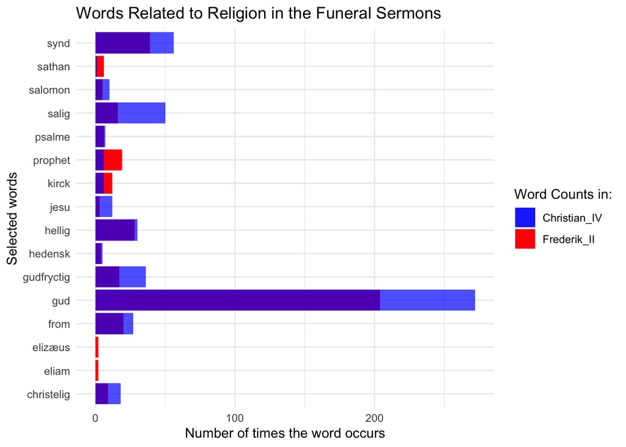

```r
religion_words <- ggplot(summary_church, aes(x = grouped_church_word)) +
  geom_col(aes(y = Frederik_II, fill = "Frederik_II"), position = position_dodge2(width = 0.9)) +
  geom_col(aes(y = Christian_IV, fill = "Christian_IV"), position = position_dodge2(width = 0.9)) +
  scale_fill_manual(values = c("Frederik_II" = "red", "Christian_IV" = alpha("blue", 0.7))) +
  labs(title = "Words Related to Religion in the Funeral Sermons", x = "Selected words", y = "Number of times the word occurs") +
  labs(fill = "Word Counts in:") +
  theme_minimal()+
  coord_flip()
religion_words
```

```r
# save it

ggsave(plot = religion_words,
       here("visualizations","religion_words.png"),
       height = 5,
       width = 8)
```

#### Titles of the Kings

In this part i will look into words regarding the titles of the kings

```r
# Grouping words related to the titles of the kings

titles_group_data <- combined_filtered %>%
  mutate(grouped_titles_word = case_when(
  grepl("fader", word, ignore.case = TRUE) ~ "fader",
  grepl("fyrst", word, ignore.case = TRUE) ~ "fyrste",
  grepl("ridder", word, ignore.case = TRUE) ~ "ridder",
  grepl("mayst|maiett", word, ignore.case = TRUE) ~ "mayst",
  word %in% c("kong", "konning") ~ "konge",
  word %in% c("herre", "herri") ~ "herre",
  TRUE ~ "andre"
  ))
```

Again i use the words to make groups with all the suffiks variations

```r
# Summarizing and counting words related to kingly titles

summary_titles <- titles_group_data %>%
  group_by(grouped_titles_word) %>%
  summarize(Frederik_II = sum(frederik_word_counts, na.rm = TRUE), Christian_IV = sum(christian_word_counts, na.rm = TRUE)) %>%
  filter(grouped_titles_word != "andre")

summary_titles
```

```
## # A tibble: 5 × 3
##   grouped_titles_word Frederik_II Christian_IV
##   <chr>                     <int>        <int>
## 1 fader                        56           43
## 2 herre                        56           64
## 3 konge                        54           35
## 4 mayst                         7           32
## 5 ridder                        2            2
```

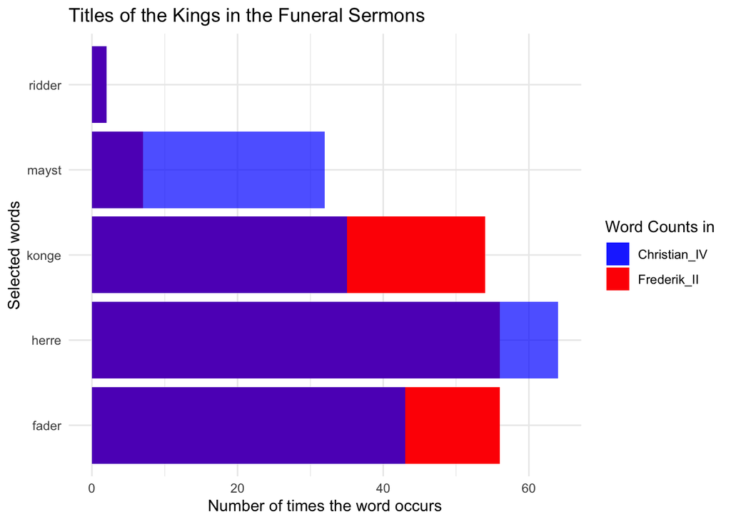

```r
# Making a graph for words regarding the titles of the kings in the funeral sermons

titles_words <- ggplot(summary_titles, aes(x = grouped_titles_word)) +
  geom_col(aes(y = Frederik_II, fill = "Frederik_II"), position = position_dodge2(width = 0.9)) +
  geom_col(aes(y = Christian_IV, fill = "Christian_IV"), position = position_dodge2(width = 0.9)) +
  scale_fill_manual(values = c("Frederik_II" = "red", "Christian_IV" = alpha("blue", 0.7))) +
  labs(title = "Titles of the Kings in the Funeral Sermons", x = "Selected words", y = "Number of times the word occurs") +
  labs(fill = "Word Counts in") +
  theme_minimal()+
  coord_flip()

titles_words
```

```r
# save it
ggsave(plot = titles_words,
       here("visualizations","titles_words.png"),
       height = 5,
       width = 8)
```

#### Personal traits

```r
# Grouping words related to Personal traits

traits_group_data <- combined_filtered %>%
  mutate(grouped_traits_word = case_when(
  grepl("from", word, ignore.case = TRUE) ~ "from",
  grepl("allernaadig", word, ignore.case = TRUE) ~ "allernaadig",
  grepl("naadig", word, ignore.case = FALSE) ~ "naadig",
  grepl("mectig", word, ignore.case = TRUE) ~ "mectig",
  grepl("viss", word, ignore.case = TRUE) ~ "viss",
  grepl("retfærd|retfer", word, ignore.case = TRUE) ~ "retfærdig",
  grepl("barmhiertig", word, ignore.case = TRUE) ~ "barmhiertig",
  grepl("dyd", word, ignore.case = TRUE) ~ "dydig",
  grepl("styrck", word, ignore.case = TRUE) ~ "styrcke",
  grepl("edel|edle", word, ignore.case = TRUE) ~ "edel",
  grepl("erlig|ærlig", word, ignore.case = TRUE) ~ "erlig",
  grepl("flitt", word, ignore.case = TRUE) ~ "flittig",
  grepl("gaffmild", word, ignore.case = TRUE) ~ "gaffmild",
  grepl("god", word, ignore.case = TRUE) ~ "god",
  grepl("modig", word, ignore.case = TRUE) ~ "modig",
  grepl("mild", word, ignore.case = TRUE) ~ "mild",
  grepl("ydmyg", word, ignore.case = TRUE) ~ "ydmyg",
  grepl("elskelig", word, ignore.case = TRUE) ~ "elskelig",
  grepl("svag", word, ignore.case = TRUE) ~ "svag",
  grepl("oprict", word, ignore.case = TRUE) ~ "oprict",
  grepl("gudfrycti", word, ignore.case = TRUE) ~ "gudfrycti",
  grepl("sactmodi", word, ignore.case = TRUE) ~ "sactmod",
  grepl("taalmodi", word, ignore.case = TRUE) ~ "taalmodig",
  grepl("klog", word, ignore.case = TRUE) ~ "klog",
  grepl("salig", word, ignore.case = TRUE) ~ "salig",
  grepl("stor", word, ignore.case = TRUE) ~ "stor",
  TRUE ~ "andre"
  ))
```

Again i use the words to make differnt groups, and summeraize and count the data into one table

```r
# Summarizing and Filtering words regarding Personal Traits

summary_traits <- traits_group_data %>%
  group_by(grouped_traits_word) %>%
  summarize(Frederik_II = sum(frederik_word_counts, na.rm = TRUE), Christian_IV = sum(christian_word_counts, na.rm = TRUE)) %>%
  filter(grouped_traits_word != "andre")

summary_traits
```

```
## # A tibble: 24 × 3
##    grouped_traits_word Frederik_II Christian_IV
##    <chr>                     <int>        <int>
##  1 allernaadig                   5           14
##  2 barmhiertig                  11            7
##  3 dydig                        15            8
##  4 edel                          5           12
##  5 elskelig                      8            7
##  6 erlig                        67           82
##  7 flittig                       5           10
##  8 from                         20           27
##  9 gaffmild                      2            0
## 10 god                          59           53
## # ℹ 14 more rows
```

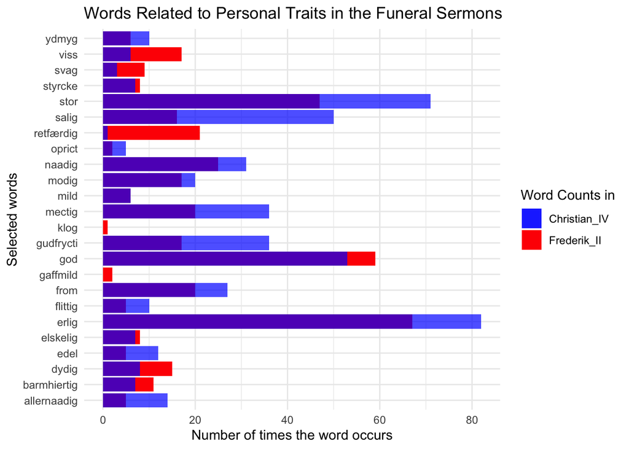

```r
# Making a visualisation regarding the personal traits used to describe the kings

traits_words <- ggplot(summary_traits, aes(x = grouped_traits_word)) +
  geom_col(aes(y = Frederik_II, fill = "Frederik_II"), position = position_dodge2(width = 0.9)) +
  geom_col(aes(y = Christian_IV, fill = "Christian_IV"), position = position_dodge2(width = 0.9)) +
  scale_fill_manual(values = c("Frederik_II" = "red", "Christian_IV" = alpha("blue", 0.7))) +
  labs(title = "Words Related to Personal Traits in the Funeral Sermons", x = "Selected words", y = "Number of times the word occurs") +
  labs(fill = "Word Counts in") +
  theme_minimal()+
  coord_flip()

traits_words
```

```r
# saving it
ggsave(plot = traits_words,
       here("visualizations","traits_words.png"),
       height = 5,
       width = 8)
```

#### Words about the king’s education and knowledge.

```r
# Making groups of words related to the kings education and knowledge

education_group_data <- combined_filtered %>%
  mutate(grouped_education_word = case_when(
  grepl("lærd", word, ignore.case = TRUE) ~ "lærd",
  grepl("klog", word, ignore.case = TRUE) ~ "klog",
  grepl("viss", word, ignore.case = TRUE) ~ "viss",
  grepl("skole", word, ignore.case = TRUE) ~ "skole",
  grepl("viss", word, ignore.case = TRUE) ~ "viss",
  grepl("latin", word, ignore.case = TRUE) ~ "latin",
  grepl("sprog", word, ignore.case = TRUE) ~ "sprog",
  grepl("bog", word, ignore.case = TRUE) ~ "bog",
  grepl("læs", word, ignore.case = TRUE) ~ "læs",
  grepl("lære", word, ignore.case = TRUE) ~ "lære",
  grepl("undervis", word, ignore.case = TRUE) ~ "undervis",
  TRUE ~ "andre"
  ))
```

Now i make groups again to gatch the different suffiks under one word.

```r
# Summarizing and Filtering Grouped Words about education and knowledge

summary_education <- education_group_data %>%
  group_by(grouped_education_word) %>%
  summarize(Frederik_II = sum(frederik_word_counts, na.rm = TRUE), Christian_IV = sum(christian_word_counts, na.rm = TRUE)) %>%
  filter(grouped_education_word != "andre")

summary_education
```

```
## # A tibble: 10 × 3
##    grouped_education_word Frederik_II Christian_IV
##    <chr>                        <int>        <int>
##  1 bog                             12            7
##  2 klog                             1            0
##  3 latin                            1            1
##  4 lærd                            16            5
##  5 lære                            17           10
##  6 læs                              7            8
##  7 skole                            9            5
##  8 sprog                            6            5
##  9 undervis                         3            1
## 10 viss                            17            6
```

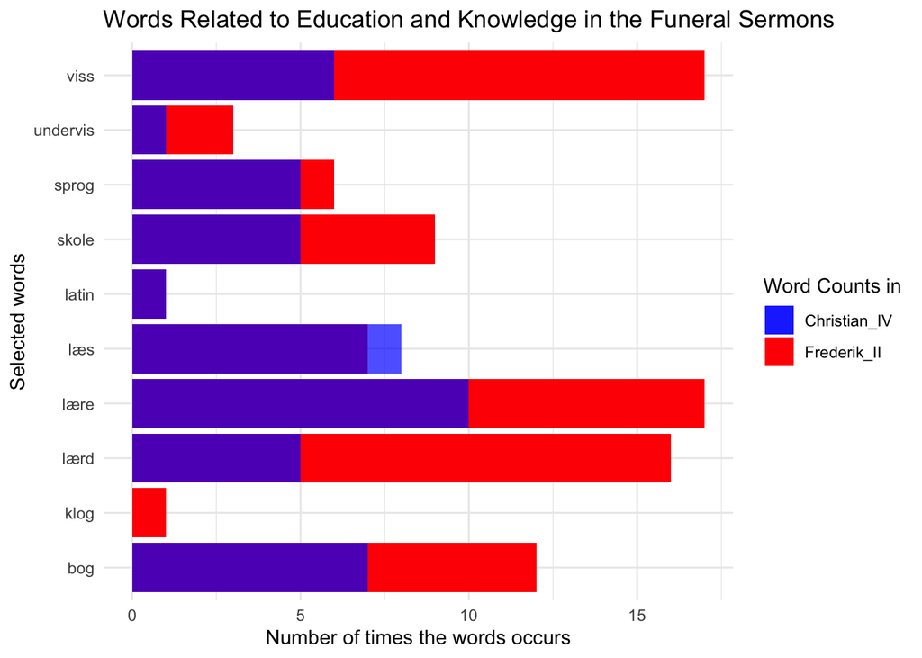

```r
# Making a plot with words regarding education

education_words <- ggplot(summary_education, aes(x = grouped_education_word)) +
  geom_col(aes(y = Frederik_II, fill = "Frederik_II"), position = position_dodge2(width = 0.9)) +
  geom_col(aes(y = Christian_IV, fill = "Christian_IV"), position = position_dodge2(width = 0.9)) +
  scale_fill_manual(values = c("Frederik_II" = "red", "Christian_IV" = alpha("blue", 0.7))) +
  labs(title = "Words Related to Education and Knowledge in the Funeral Sermons", x = "Selected words", y = "Number of times the words occurs") +
  labs(fill = "Word Counts in") +
  theme_minimal()+
  coord_flip()

education_words
```

```r
# saving it
ggsave(plot = education_words,
       here("visualizations","education_words.png"),
       height = 5,
       width = 8)
```

#### Looking at words about war and Foreign Policy

In this section i will be making visualizations with words related to war and crisis, this is important because in both Christian and Frederik’s periode of reign, Denmark was involved in several wars. And it is exiting to see if the picture has changed.

```r
# Grouping Adjectives about war and crisis

war_group_data <- combined_filtered %>%
  mutate(grouped_war_word = case_when(
    grepl("ridder", word, ignore.case = TRUE) ~ "ridder",
    grepl("feide", word, ignore.case = TRUE) ~ "feide",
    grepl("blodebad", word, ignore.case = TRUE) ~ "blodebad",
    grepl("farlig", word, ignore.case = TRUE) ~ "farlig",
    grepl("blodebad", word, ignore.case = TRUE) ~ "blodebad",
    grepl("straf", word, ignore.case = TRUE) ~ "straf",
    grepl("styrcke", word, ignore.case = TRUE) ~ "styrcke",
    word %in% c("modig", "modige") ~ "modig",
    grepl("krig", word, ignore.case = TRUE) ~ "krig",
    grepl("modgang", word, ignore.case = TRUE) ~ "modgang",
    grepl("strid", word, ignore.case = TRUE) ~ "strid",
    grepl("hær", word, ignore.case = TRUE) ~ "hær",
    grepl("soldat", word, ignore.case = TRUE) ~ "soldat",
    grepl("sverd", word, ignore.case = TRUE) ~ "sverd",
    grepl("ufred", word, ignore.case = TRUE) ~ "ufred",
    grepl("kamp", word, ignore.case = TRUE) ~ "kamp",
    grepl("fred", word, ignore.case = TRUE) ~ "fred",
    TRUE ~ "andre"
  ))
```

Again i use the words to make differnt groups

```r
# Summarizing and Filtering Grouped war word counts

summary_war <- war_group_data %>%
  group_by(grouped_war_word) %>%
  summarize(Frederik_II = sum(frederik_word_counts, na.rm = TRUE), Christian_IV = sum(christian_word_counts, na.rm = TRUE)) %>%
  filter(grouped_war_word != "andre")

summary_war
```

```
## # A tibble: 14 × 3
##    grouped_war_word Frederik_II Christian_IV
##    <chr>                  <int>        <int>
##  1 blodebad                   1            0
##  2 farlig                     6            4
##  3 feide                      6            2
##  4 fred                      28           35
##  5 hær                        3            3
##  6 krig                      16            4
##  7 modgang                    0            7
##  8 modig                      4            6
##  9 ridder                     2            2
## 10 straf                     18           20
## 11 strid                      3           10
## 12 styrcke                    8            6
## 13 sverd                      1            1
## 14 ufred                      1            1
```

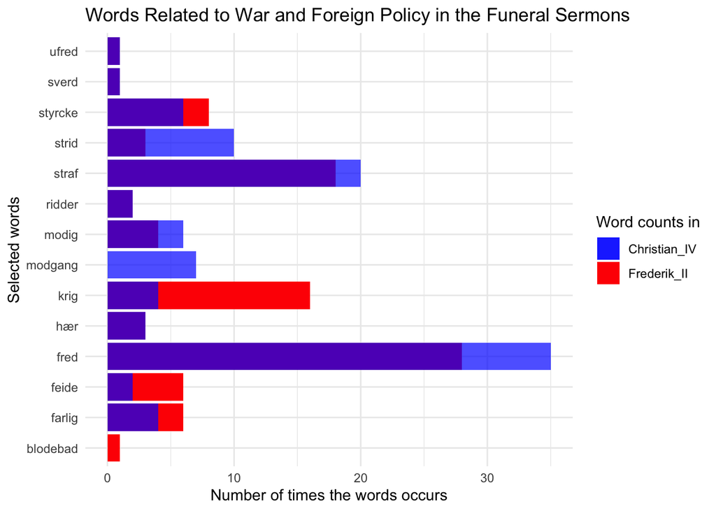

```r
# Visualizing words about war and Foreign Policy

war_words <- ggplot(summary_war, aes(x = grouped_war_word)) +
   geom_col(aes(y = Frederik_II, fill = "Frederik_II"), position = position_dodge2(width = 0.9)) +
  geom_col(aes(y = Christian_IV, fill = "Christian_IV"), position = position_dodge2(width = 0.9)) +
  scale_fill_manual(values = c("Frederik_II" = "red", "Christian_IV" = alpha("blue", 0.7))) +
  labs(title = "Words Related to War and Foreign Policy in the Funeral Sermons", x = "Selected words", y = "Number of times the words occurs") +
  labs(fill = "Word counts in") +
  theme_minimal()+
  coord_flip()

war_words
```

```r
# saving it
ggsave(plot = war_words,
       here("visualizations","war_words.png"),
       height = 5,
       width = 8)
```

#### Subjects’ groups, other persons

How was the kings subjects portrayed?

```r
# Grouping words about Subjects and other groups in the funeral sermons

subjects_group_data <- combined_filtered %>%
  mutate(grouped_subjects_word = case_when(
    grepl("keyser", word, ignore.case = TRUE) ~ "keyser",
    grepl("folk", word, ignore.case = TRUE) ~ "folk",
    grepl("mand|mænd", word, ignore.case = TRUE) ~ "mand",
    grepl("undersaat", word, ignore.case = TRUE) ~ "undersaat",
    grepl("regier|regærin", word, ignore.case = TRUE) ~ "regiering",
    grepl("bønde|bonde", word, ignore.case = TRUE) ~ "bønder",
    grepl("borger", word, ignore.case = TRUE) ~ "borger",
    grepl("fatti", word, ignore.case = TRUE) ~ "fatti",
    grepl("quind", word, ignore.case = TRUE) ~ "quinde",
    grepl("adel", word, ignore.case = TRUE) ~ "adel",
    grepl("klerck", word, ignore.case = TRUE) ~ "klerck",
    grepl("indbyg", word, ignore.case = TRUE) ~ "indbyggere",
    grepl("almue", word, ignore.case = TRUE) ~ "almue",
    grepl("klerck", word, ignore.case = TRUE) ~ "klerck",
    TRUE ~ "andre"
  ))
```

```r
# Summarizing and Filtering Groups about Subjects and groups

summary_subjects <- subjects_group_data %>%
  group_by(grouped_subjects_word) %>%
  summarize(Frederik_II = sum(frederik_word_counts, na.rm = TRUE), Christian_IV = sum(christian_word_counts, na.rm = TRUE)) %>%
  filter(grouped_subjects_word != "andre")

summary_subjects
```

```
## # A tibble: 12 × 3
##    grouped_subjects_word Frederik_II Christian_IV
##    <chr>                       <int>        <int>
##  1 adel                           17           14
##  2 almue                           1            0
##  3 borger                          4            3
##  4 bønder                          4            1
##  5 fatti                           8            9
##  6 indbyggere                      9            8
##  7 keyser                          7            2
##  8 klerck                          1            0
##  9 mand                           54           28
## 10 quinde                          3            1
## 11 regiering                       2           47
## 12 undersaat                       6           29
```

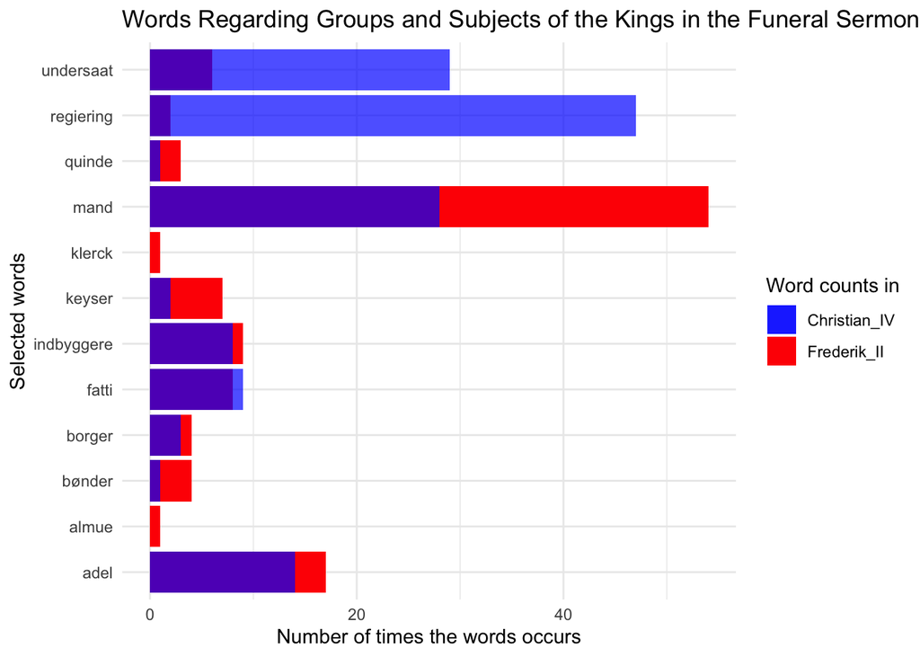

```r
# Summarizing and Filtering Groups about Subjects and groups

subjects_words <- ggplot(summary_subjects, aes(x = grouped_subjects_word)) +
  geom_col(aes(y = Frederik_II, fill = "Frederik_II"), position = position_dodge2(width = 0.9)) +
  geom_col(aes(y = Christian_IV, fill = "Christian_IV"), position = position_dodge2(width = 0.9)) +
  scale_fill_manual(values = c("Frederik_II" = "red", "Christian_IV" = alpha("blue", 0.7))) +
  labs(title = "Words Regarding Groups and Subjects of the Kings in the Funeral Sermons", x = "Selected words", y = "Number of times the words occurs") +
  labs(fill = "Word counts in") +
  theme_minimal()+
  coord_flip()

subjects_words
```

```r
# saving it
ggsave(plot = subjects_words,
       here("visualizations","subjects_words.png"),
       height = 5,
       width = 8)
```

#### Words presenting the status of the king

Christian IV was a very famous danish king, and many times his wealth and high status has been in focus, therefore it is interessting how and which words was used to describe the status of the king

```r
# Grouping Adjectives about the status of the kings

status_group_data <- combined_filtered %>%
  mutate(grouped_status_word = case_when(
    grepl("guld", word, ignore.case = TRUE) ~ "guld",
    grepl("rigdom", word, ignore.case = TRUE) ~ "rigdom",
    grepl("høyloffl", word, ignore.case = TRUE) ~ "høylofflig",
    grepl("ophøy", word, ignore.case = TRUE) ~ "ophøyet",
    grepl("berøm", word, ignore.case = TRUE) ~ "berømt",
    grepl("høyborn|høybaarn", word, ignore.case = TRUE) ~ "høyborn",
    grepl("mectig", word, ignore.case = TRUE) ~ "mectig",
    TRUE ~ "andre"
  ))
```

```r
# Gathering the words under each group

summary_status <- status_group_data %>%
  group_by(grouped_status_word) %>%
  summarize(Frederik_II= sum(frederik_word_counts, na.rm = TRUE), Christian_IV = sum(christian_word_counts, na.rm = TRUE)) %>%
  filter(grouped_status_word != "andre")

summary_status
```

```
## # A tibble: 7 × 3
##   grouped_status_word Frederik_II Christian_IV
##   <chr>                     <int>        <int>
## 1 berømt                        3           30
## 2 guld                          1            3
## 3 høyborn                      14           25
## 4 høylofflig                    8           10
## 5 mectig                       20           36
## 6 ophøyet                       1            6
## 7 rigdom                        2           12
```

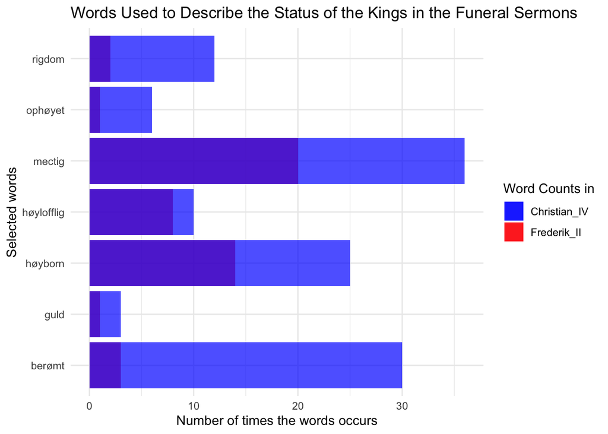

```r
# First glimps of the words used to describe the status of the kings

ggplot(summary_status, aes(x = grouped_status_word)) +
  geom_col(aes(y = Frederik_II, fill = "Frederik_II"), position = position_dodge(width = 0.5)) +
  geom_col(aes(y = Christian_IV, fill = "Christian_IV"), position = position_dodge(width = 3.0)) +
  scale_fill_manual(values = c("Frederik_II" = alpha("red", 0.7), "Christian_IV" = alpha("blue", 0.7))) +
  labs(title = "Words Used to Describe the Status of the Kings in the Funeral Sermons", x = "Selected words", y = "Number of times the words occurs") +
  labs(fill = "Word Counts in") +
  theme_minimal() +
  coord_flip()
```

In the plot above, there are some problems - because the majority of words occurred most frequently in Christian IV’s funeral sermon, and therefore the red color became is challenging to discern. While I aimed to uphold a uniform visual style across all my visualizations, it is crucial in effective data visualization to guarantee that the information remains clear and easily comprehensible. Therefore i will try to change the graph. I will change the way the bars overlap:

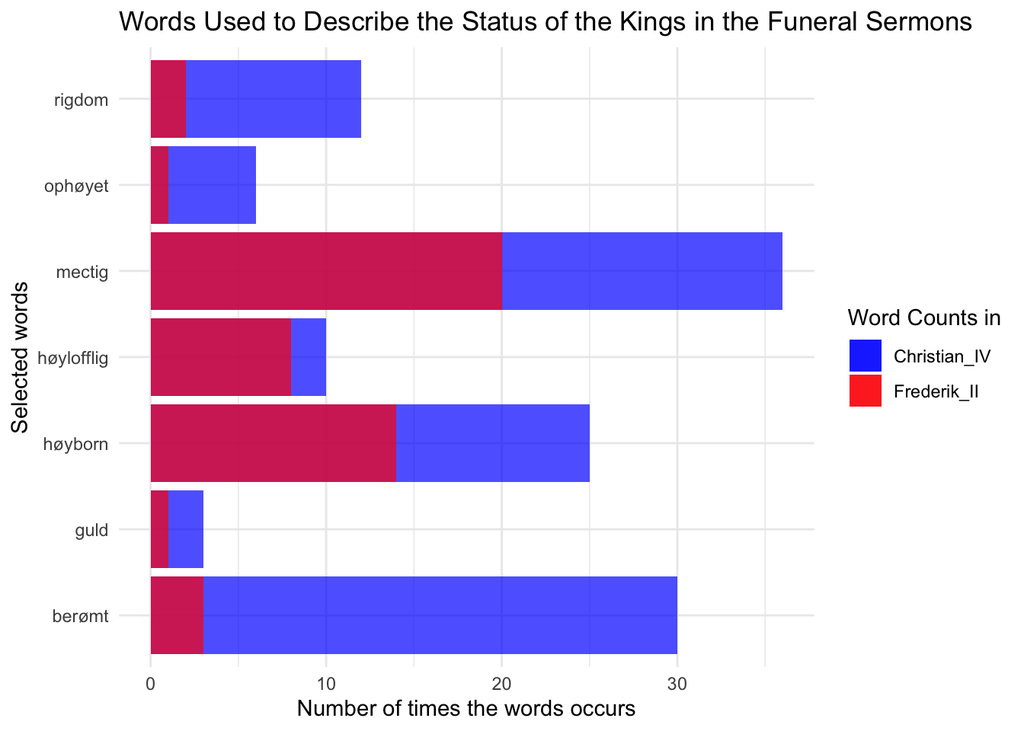

```r
# Trying to make another visualization

ggplot(summary_status, aes(x = grouped_status_word)) +
  geom_col(aes(y = Christian_IV, fill = "Christian_IV")) +
  geom_col(aes(y = Frederik_II, fill = "Frederik_II")) +
  scale_fill_manual(values = c("Frederik_II" = alpha("red",0.7), "Christian_IV" = alpha("blue", 0.7))) +
  labs(title = "Words Used to Describe the Status of the Kings in the Funeral Sermons", x = "Selected words", y = "Number of times the words occurs") +
  labs(fill = "Word Counts in") +
  theme_minimal() +
  coord_flip()
```

But this graph is also bad, now you don’t now if the blue color goes all the way back to 0 word counts, or just starts were the red color ends. Also you dont know how many times the word “høylofflig” appears in the funeral sermon of Christian IV. (This graph is also not good) Therefore again i will try to make another one, where you can see were the colors starts - and where the other one ends:

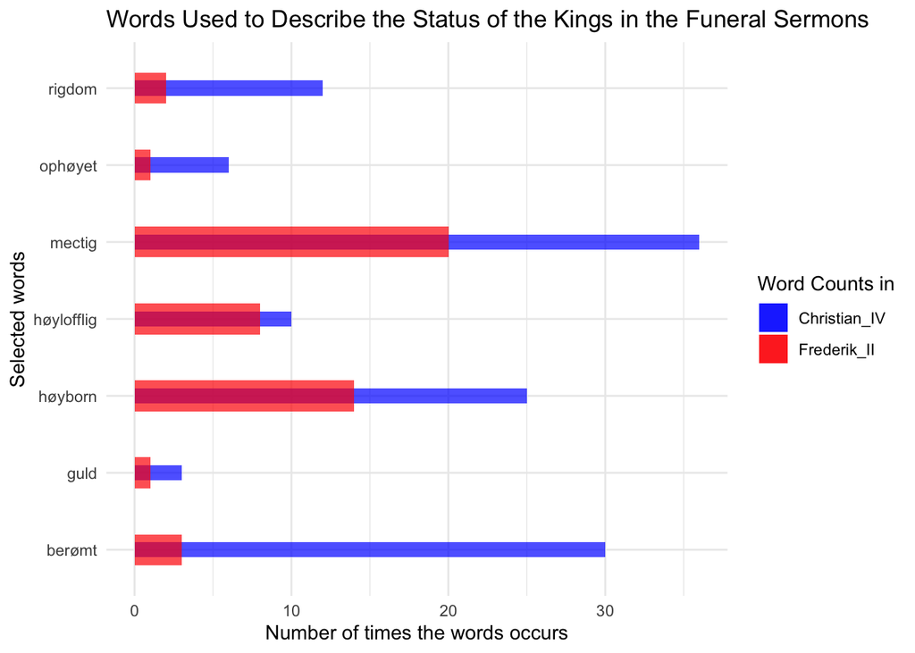

```r
# Trying to make the visualisation better

status_words <- ggplot(summary_status, aes(x = grouped_status_word)) +
  geom_bar(aes(y = Christian_IV, fill = "Christian_IV"), stat = "identity", width = 0.2) +
  geom_bar(aes(y = Frederik_II, fill = "Frederik_II"), stat = "identity", width = 0.4) +
  scale_fill_manual(values = c("Frederik_II" = alpha("red", 0.7), "Christian_IV" = alpha("blue", 0.7))) +
  labs(title = "Words Used to Describe the Status of the Kings in the Funeral Sermons", x = "Selected words", y = "Number of times the words occurs") +
  labs(fill = "Word Counts in") +
  theme_minimal() +
  coord_flip()

status_words
```

```r
# saving it
ggsave(plot = status_words,
       here("visualizations","status_words.png"),
       height = 5,
       width = 8)
```

This graph is much better, now you can better distinguish between the wordcounts, and see the data from Frederik IIs sermon

Thank you for looking at my project, for another file-format look in my Github repository, in the “My Final Project folder” https://github.com/Digital-Methods-HASS/au728030_beuschau_mia/tree/main